# Commercial landings of Thorny skate

Ricky Tabandera

28 Dec 2020

## Commercial Landings of thorny skate

This data was sourced from [FOSS - Fisheries One Stop Shop](https://foss.nmfs.noaa.gov/apexfoss/f?p=215:200:4615327020711::NO:::) and is inclusive of 1950 to 2019. The entire data set contains 232 species. A total of 9656 aggrigated records were removed. These landing reports were aggrigations of mutiple species and can span several taxanomic groups were removied due to their lack of specificity. 5019 records were withheld due to confidentiality of thoese specific landings. Figures produced reflect the coverage of the data. With stocks that have high coverage, a running average is calculated. In low coverage stocks, missing values are excluded and a simple time series is produced.

[figure not shown]

## Commercial landings of thorny skate across states in the mid-Atlantic and north-east regions

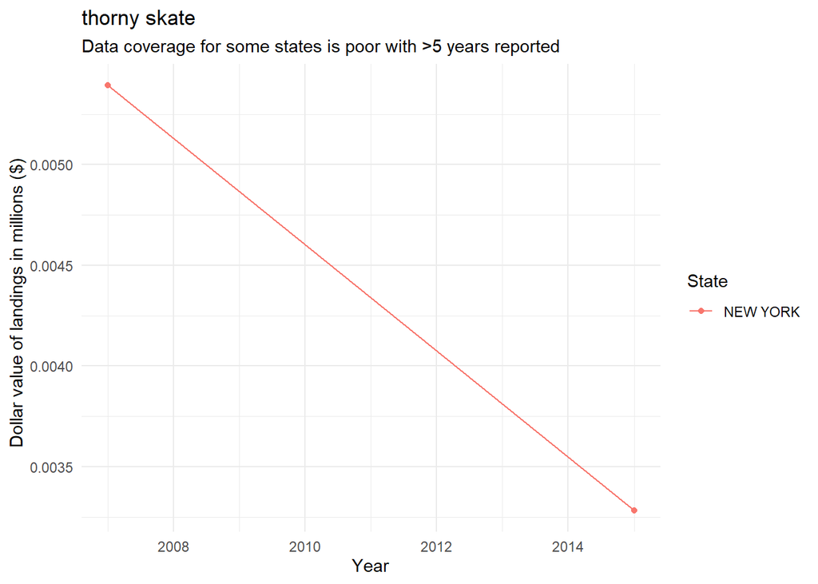

## Non-inflation adjusted price history of thorny skate

The calculated price is dollars per pound of reported landings.

[figure not shown]

## Non-inflation adjusted price history of thorny skate across states in the mid-Atlantic and north-east regions

The calculated price is dollars per pound of reported landings.

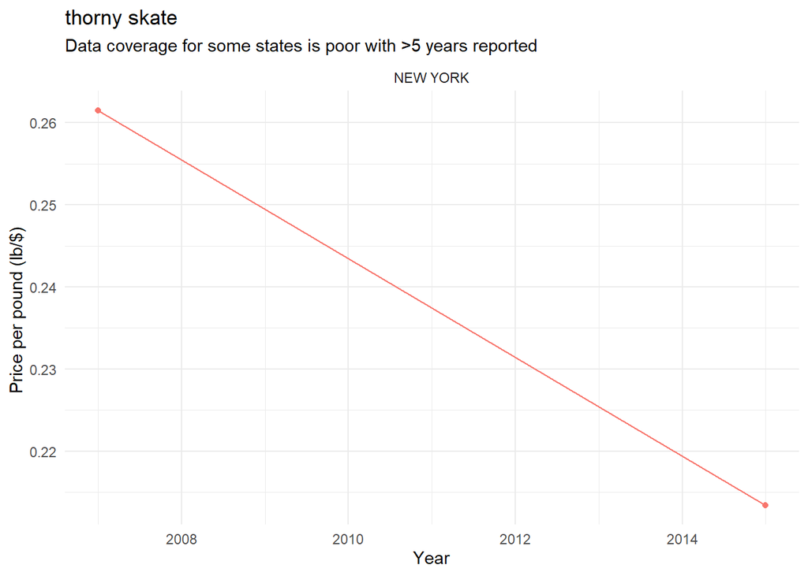

## inflation adjusted price history of thorny skate

The price history of thorny skate adjusted to 2019 values using data from the World Bank inflation data as informed by Inflation adjustment calculations in Principles of Macroeconomics by Gregory Mankiw et al (2014). Adjustements perfomed using the packages priceR.

```
## Generating URL to request all 304 results
## Retrieving inflation data for US
## Generating URL to request all 61 results
```

[figure not shown]

## inflation adjusted price history of thorny skate across states in the mid-Atlantic and north-east regions

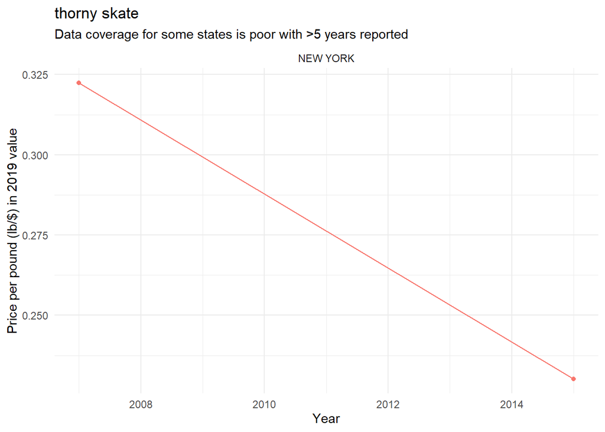